# Battle of the Neighborhoods: - Finding a good place to live in Atlanta

```python
import requests
import pandas as pd

from bs4 import BeautifulSoup
import requests
import urllib
import urllib.request

import re

import pandas as pd
import numpy as np

import matplotlib.pyplot as plt
%matplotlib inline
```

```python
# Initiation so we can map later
from geopy.geocoders import Nominatim

import folium

from pandas.io.json import json_normalize

address = 'Atlanta, Georgia'

geolocator = Nominatim(user_agent="atlanta_explorer")
location = geolocator.geocode(address)
latitude = location.latitude
longitude = location.longitude
print('The geograpical coordinate of Atlanta are {}, {}.'.format(latitude, longitude))
```

```
The geograpical coordinate of Atlanta are 33.7490987, -84.3901849.
```

## Introduction

For the last couple of labs and home work sessions in the class, we have had chance to analyze New York City, San Francisco, and Toronto data. I am working with my sister to finalize her move to Atlanta, US. And during her move to the US, we are mainly interested in find a nice and safe neighborhood for her to stay at.

Thus, in this project, we will analyze venues and crime data Atlanta. We will try to find the best place to live in Atlanta based on safety and our interest.

The use of this analysis can be expand to anyone who is interested in moving to Atlanta.

## Data Description

#### Atalanta Crime Data

The data can be downloaded from: https://www.atlantapd.org/i-want-to/crime-data-downloads

Example of the data can be seen below:

```python
crime = pd.read_csv('COBRA-2009-2019.csv')
crime.head()
```

|  | Report Number | Report Date | Occur Date | Occur Time | Possible Date | Possible Time | Beat | Apartment Office Prefix | Apartment Number | Location | Shift Occurence | Location Type | UCR Literal | UCR # | IBR Code | Neighborhood | NPU | Latitude | Longitude |
| --- | --- | --- | --- | --- | --- | --- | --- | --- | --- | --- | --- | --- | --- | --- | --- | --- | --- | --- | --- |
| 0 | 90010930 | 2009-01-01 | 2009-01-01 | 1145 | 2009-01-01 | 1148.0 | 411.0 | NaN | NaN | 2841 GREENBRIAR PKWY | Day Watch | 8 | LARCENY-NON VEHICLE | 630 | 2303 | Greenbriar | R | 33.68845 | -84.49328 |
| 1 | 90011083 | 2009-01-01 | 2009-01-01 | 1330 | 2009-01-01 | 1330.0 | 511.0 | NaN | NaN | 12 BROAD ST SW | Day Watch | 9 | LARCENY-NON VEHICLE | 630 | 2303 | Downtown | M | 33.75320 | -84.39201 |
| 2 | 90011208 | 2009-01-01 | 2009-01-01 | 1500 | 2009-01-01 | 1520.0 | 407.0 | NaN | NaN | 3500 MARTIN L KING JR DR SW | Unknown | 8 | LARCENY-NON VEHICLE | 630 | 2303 | Adamsville | H | 33.75735 | -84.50282 |
| 3 | 90011218 | 2009-01-01 | 2009-01-01 | 1450 | 2009-01-01 | 1510.0 | 210.0 | NaN | NaN | 3393 PEACHTREE RD NE | Evening Watch | 8 | LARCENY-NON VEHICLE | 630 | 2303 | Lenox | B | 33.84676 | -84.36212 |
| 4 | 90011289 | 2009-01-01 | 2009-01-01 | 1600 | 2009-01-01 | 1700.0 | 411.0 | NaN | NaN | 2841 GREENBRIAR PKWY SW | Unknown | 8 | LARCENY-NON VEHICLE | 630 | 2303 | Greenbriar | R | 33.68677 | -84.49773 |

```python
crime.shape
```

```
(342914, 19)
```

#### Foursquare API

Like in other labs, we will use Foursquare API to get venue information.

Example of the data can be seen below

```python
example_df = crime[['Neighborhood','Latitude','Longitude']].loc[0:3,]
example_df
```

|  | Neighborhood | Latitude | Longitude |
| --- | --- | --- | --- |
| 0 | Greenbriar | 33.68845 | -84.49328 |
| 1 | Downtown | 33.75320 | -84.39201 |
| 2 | Adamsville | 33.75735 | -84.50282 |
| 3 | Lenox | 33.84676 | -84.36212 |

```python
CLIENT_ID = 'HFL0RQARIH2YPHFZFHQWPDIHWJF4XC3BBY3PWEELDFDAXTZL' # your Foursquare ID
CLIENT_SECRET ='ARGKXWTQXFUJHASLN0NDVD4G2KOWC2L03MOO01G4SHW3QW0D' # your Foursquare Secret
VERSION = '20200101' # Foursquare API version

radius = 500 # define radius
def getNearbyVenues(group_names, location_col_name, latitudes, longitudes, limit, radius=500):

    venues_list=[]
    for name, lat, lng in zip(group_names, latitudes, longitudes):
        print(name)

        # create the API request URL
        url = 'https://api.foursquare.com/v2/venues/explore?&client_id={}&client_secret={}&v={}&ll={},{}&radius={}&limit={}'.format(
            CLIENT_ID,
            CLIENT_SECRET,
            VERSION,
            lat,
            lng,
            radius,
            limit)

        # make the GET request
        results = requests.get(url).json()["response"]['groups'][0]['items']

        # return only relevant information for each nearby venue
        venues_list.append([(
            name,
            lat,
            lng,
            v['venue']['name'],
            v['venue']['location']['lat'],
            v['venue']['location']['lng'],
            v['venue']['categories'][0]['name']) for v in results])

    nearby_venues = pd.DataFrame([item for venue_list in venues_list for item in venue_list])
    nearby_venues.columns = ['Neighborhood',
                  location_col_name+' Latitude',
                  location_col_name+' Longitude',
                  'Venue',
                  'Venue Latitude',
                  'Venue Longitude',
                  'Venue Category']

    return(nearby_venues)

example = getNearbyVenues(group_names=example_df['Neighborhood'],
                          location_col_name = 'Neighborhood',
                          latitudes=example_df['Latitude'],
                          longitudes=example_df['Longitude'],
                          limit=1,
                          radius=500
                         )

example
```

```
Greenbriar
Downtown
Adamsville
Lenox
```

|  | Neighborhood | Neighborhood Latitude | Neighborhood Longitude | Venue | Venue Latitude | Venue Longitude | Venue Category |
| --- | --- | --- | --- | --- | --- | --- | --- |
| 0 | Greenbriar | 33.68845 | -84.49328 | Planet Fitness | 33.687053 | -84.491564 | Gym / Fitness Center |
| 1 | Downtown | 33.75320 | -84.39201 | Jamrock Restaurant | 33.751554 | -84.391356 | Caribbean Restaurant |
| 2 | Adamsville | 33.75735 | -84.50282 | Planet Fitness | 33.759286 | -84.504357 | Gym / Fitness Center |
| 3 | Lenox | 33.84676 | -84.36212 | Forum Athletic Club | 33.846695 | -84.361770 | Gym |

## Methodology

Since we will only use aggregate data for each neighborhood in our analysis, we will only pick the columns UCR Literal, Neighborhood, NPU, Latitude, and Longitude.

```python
crime = crime[['UCR Literal', 'Neighborhood', 'NPU', 'Latitude', 'Longitude']]
crime = crime.rename({'UCR Literal':'crime_type'},axis=1)
crime.head()
```

|  | crime_type | Neighborhood | NPU | Latitude | Longitude |
| --- | --- | --- | --- | --- | --- |
| 0 | LARCENY-NON VEHICLE | Greenbriar | R | 33.68845 | -84.49328 |
| 1 | LARCENY-NON VEHICLE | Downtown | M | 33.75320 | -84.39201 |
| 2 | LARCENY-NON VEHICLE | Adamsville | H | 33.75735 | -84.50282 |
| 3 | LARCENY-NON VEHICLE | Lenox | B | 33.84676 | -84.36212 |
| 4 | LARCENY-NON VEHICLE | Greenbriar | R | 33.68677 | -84.49773 |

Since a neighborhood might span multiple NPUs. And each NPU has different government structure, it might affect the crime rate and type. Let's see if we have any neighborhood that fit those criteria.

```python
(crime[['Neighborhood', 'NPU']].
 groupby(['Neighborhood', 'NPU']).size().reset_index().drop(0,axis=1).
 groupby('Neighborhood').size()
)
```

```
Neighborhood
Adair Park             1
Adams Park             3
Adamsville             1
Almond Park            2
Amal Heights           1
                      ..
Wilson Mill Meadows    1
Wisteria Gardens       1
Woodfield              1
Woodland Hills         1
Wyngate                1
Length: 243, dtype: int64
```

Ideally, we would want to break down Neighborhood by its NPU, but my main concern is that it will make the geographic very fragmented. So let's keep the Neighborhood only.

```python
crime.drop('NPU',axis=1,inplace=True)
crime.head(3)
```

|  | crime_type | Neighborhood | Latitude | Longitude |
| --- | --- | --- | --- | --- |
| 0 | LARCENY-NON VEHICLE | Greenbriar | 33.68845 | -84.49328 |
| 1 | LARCENY-NON VEHICLE | Downtown | 33.75320 | -84.39201 |
| 2 | LARCENY-NON VEHICLE | Adamsville | 33.75735 | -84.50282 |

Let's take a look at the type of crime happens in Atalanta

```python
crime['crime_type'].unique()
```

```
array(['LARCENY-NON VEHICLE', 'LARCENY-FROM VEHICLE',
       'ROBBERY-PEDESTRIAN', 'ROBBERY-RESIDENCE', 'AUTO THEFT',
       'AGG ASSAULT', 'BURGLARY-RESIDENCE', 'BURGLARY-NONRES',
       'ROBBERY-COMMERCIAL', 'HOMICIDE', 'MANSLAUGHTER'], dtype=object)
```

We can see that the crime types is divided into 2 components, main and sub crime types for Lacerny, Robbery, and Burglary. In order to unfragmentize our analysis, we will only take the main type of crime.

```python
crime['crime_type'] = crime['crime_type'].apply(lambda x: x.split('-')[0])
crime.head(3)
```

|  | crime_type | Neighborhood | Latitude | Longitude |
| --- | --- | --- | --- | --- |
| 0 | LARCENY | Greenbriar | 33.68845 | -84.49328 |
| 1 | LARCENY | Downtown | 33.75320 | -84.39201 |
| 2 | LARCENY | Adamsville | 33.75735 | -84.50282 |

Let's look at the top crime for each neighborhood.

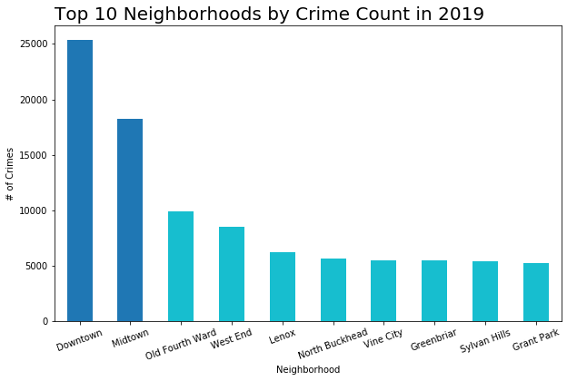

```python
hood_crime = crime['Neighborhood'].value_counts()
hood_crime_top10 = hood_crime[0:10]

top_10 = hood_crime_top10.plot(kind='bar',figsize=(10, 6),color='tab:cyan')
top_10.patches[hood_crime_top10.index.get_indexer(['Downtown'])[0]].set_facecolor('tab:blue')
top_10.patches[hood_crime_top10.index.get_indexer(['Midtown'])[0]].set_facecolor('tab:blue')

plt.xlabel('Neighborhood') # add to x-label to the plot
plt.ylabel('# of Crimes') # add y-label to the plot
plt.title('Top 10 Neighborhoods by Crime Count in 2019',fontsize = 20,loc='left')
plt.xticks(rotation=20)

plt.show()
```

Let's look at the most common type of crime in Atlanta

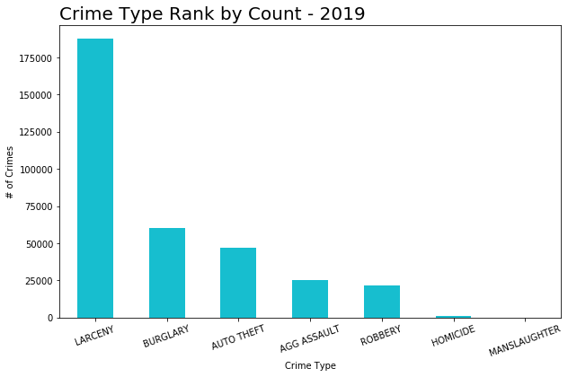

```python
crime_type_top10 = crime['crime_type'].value_counts()

crime_type_top10.plot(kind='bar',figsize=(10, 6),color='tab:cyan')

plt.xlabel('Crime Type') # add to x-label to the plot
plt.ylabel('# of Crimes') # add y-label to the plot
plt.title('Crime Type Rank by Count - 2019',fontsize = 20,loc='left')
plt.xticks(rotation=20)

plt.show()
```

So we have 7 main types of crime in total, with Lacerny and Burglary at the top.

Next, let's pitvot the data frame so that we have count for each type of crime as columns.

```python
crime_count = (crime[['crime_type','Neighborhood']].
               groupby(['Neighborhood','crime_type']).
               size().reset_index().rename(columns={0:'count'}).
               pivot_table(index='Neighborhood',columns='crime_type',
                           values='count',fill_value=0). # Pivot to get the count in to cols.
               reset_index(). # Get hood_npu back into the data frame
               rename_axis(None,axis=1) # Need to remove index name so it's less annoying
              )
print(crime_count.shape)
crime_count.head()
```

```
(243, 8)
```

|  | Neighborhood | AGG ASSAULT | AUTO THEFT | BURGLARY | HOMICIDE | LARCENY | MANSLAUGHTER | ROBBERY |
| --- | --- | --- | --- | --- | --- | --- | --- | --- |
| 0 | Adair Park | 198 | 343 | 414 | 13 | 839 | 0 | 205 |
| 1 | Adams Park | 114 | 202 | 398 | 4 | 654 | 0 | 132 |
| 2 | Adamsville | 304 | 419 | 492 | 11 | 1302 | 0 | 270 |
| 3 | Almond Park | 124 | 152 | 272 | 12 | 215 | 0 | 75 |
| 4 | Amal Heights | 45 | 75 | 140 | 0 | 97 | 0 | 15 |

#### Neighborhood coordinate

Since we can't reliably and easily get neighborhood longitude and latitude from any of the website or data source. We will use a work around from our crime database. First, we will find the centroids of all crime points by neighborhood in our data frame. This will give us a rough estimate of the center point of that neighborhood.

Normally to find the centroid for a collection of longitudes and latitude is actually a little bit more complicated than simply averaging longtitude and latitude. This is because the as we approach and cross the intermedian or the poles, the longitude and latitude change their sign to signify the change in coordinates. For example -179 longitude and 179 longitude points are actually very close to each other. However, the average for those 2 longitude is 0, which is halfway across the world.

However, since all of our neighborhood is based in Atlanta, so the points for each neighborhood is not too far apart, and most importantly, Atlanta doesn't spread through the intermedian, or is anywhere close to the poles. Thus, we will examine the dataframe to see the range of longitude and latitude given. If there is no sign changed, we can treat all points in the dataframe as a flat database and simply use the arithmetic mean to find the centroid. This can easily be done by seeing the std and min max of longitude and latitude.

If we detect a change in coordinates signs, we will choose a different method in finding the centroid. The most accurate method I found online would be to utilize the center of gravity method. To perform this method, we convert longitude and latitude into Cartesian (x,y,z) coordinates. The average x, y and z coordinate is calculated. This average coordinate lies within the interior of the earth and is the true center of mass, and a line can be drawn from the center of the earth passing through this point then out to the surface of the earth which is the geographic midpoint. The average x, y and z coordinate is converted into the latitude and longitude for the midpoint.

You can find more information about calculating geographic mid point [here](http://www.geomidpoint.com/calculation.html) or [here](https://carto.com/blog/center-of-points/) to calculate the geographic midpoint.

Let's check the range of lat and lon in our dataframe.

```python
crime[['Neighborhood','Latitude','Longitude']].describe()
```

|  | Latitude | Longitude |
| --- | --- | --- |
| count | 342914.000000 | 342914.000000 |
| mean | 33.757281 | -84.407407 |
| std | 0.044930 | 0.047112 |
| min | 33.637500 | -84.550500 |
| 25% | 33.730310 | -84.432130 |
| 50% | 33.756670 | -84.396360 |
| 75% | 33.781830 | -84.373470 |
| max | 33.886130 | -84.286410 |

So luckily, the coordinates in our dataframe are very close, and we see no sign change. We can go ahead and use simple averaging for this exercise.

```python
crime_loc = (crime[['Neighborhood','Latitude','Longitude']].
             groupby('Neighborhood').
             mean().reset_index()
            )

print(crime_loc.shape)
crime_loc.head()
```

```
(243, 3)
```

|  | Neighborhood | Latitude | Longitude |
| --- | --- | --- | --- |
| 0 | Adair Park | 33.729698 | -84.410426 |
| 1 | Adams Park | 33.713987 | -84.460214 |
| 2 | Adamsville | 33.758748 | -84.503608 |
| 3 | Almond Park | 33.784186 | -84.460470 |
| 4 | Amal Heights | 33.708719 | -84.398984 |

Let's merge back the crime_loc and crime_count data frame to get the neighborhood crime count and location

```python
alt_hood_crime = crime_loc.merge(crime_count,how='left',on='Neighborhood')
print(alt_hood_crime.shape)
alt_hood_crime.head(4)
```

```
(243, 10)
```

|  | Neighborhood | Latitude | Longitude | AGG ASSAULT | AUTO THEFT | BURGLARY | HOMICIDE | LARCENY | MANSLAUGHTER | ROBBERY |
| --- | --- | --- | --- | --- | --- | --- | --- | --- | --- | --- |
| 0 | Adair Park | 33.729698 | -84.410426 | 198 | 343 | 414 | 13 | 839 | 0 | 205 |
| 1 | Adams Park | 33.713987 | -84.460214 | 114 | 202 | 398 | 4 | 654 | 0 | 132 |
| 2 | Adamsville | 33.758748 | -84.503608 | 304 | 419 | 492 | 11 | 1302 | 0 | 270 |
| 3 | Almond Park | 33.784186 | -84.460470 | 124 | 152 | 272 | 12 | 215 | 0 | 75 |

Let's define a function to return the most common categories for a dataframe. This will be used to determine the most common crime, and most common venues later on

```python
def most_common(row, start_index, top_num):
    """Function to return the most X numbers by categories
    start_index is the index of columns where your categories begin.
    """
    row_categories = row.iloc[start_index:]
    row_categories_sorted = row_categories.sort_values(ascending=False)

    return row_categories_sorted.index.values[0:top_num]
```

```python
num_top_crimes = 7

indicators = ['st', 'nd', 'rd']

# create columns according to number of top venues
columns = ['Neighborhood']
for ind in np.arange(num_top_crimes):
    try:
        columns.append('{}{} Most Common Crime'.format(ind+1, indicators[ind]))
    except:
        columns.append('{}th Most Common Crime'.format(ind+1))

# create a new dataframe
atl_crime_sorted = pd.DataFrame(columns=columns)
atl_crime_sorted['Neighborhood'] = alt_hood_crime['Neighborhood']

for ind in np.arange(alt_hood_crime.shape[0]):
    atl_crime_sorted.iloc[ind, 1:] = most_common(alt_hood_crime.iloc[ind, :],3,num_top_crimes)

atl_crime_sorted.head()
```

|  | Neighborhood | 1st Most Common Crime | 2nd Most Common Crime | 3rd Most Common Crime | 4th Most Common Crime | 5th Most Common Crime | 6th Most Common Crime | 7th Most Common Crime |
| --- | --- | --- | --- | --- | --- | --- | --- | --- |
| 0 | Adair Park | LARCENY | BURGLARY | AUTO THEFT | ROBBERY | AGG ASSAULT | HOMICIDE | MANSLAUGHTER |
| 1 | Adams Park | LARCENY | BURGLARY | AUTO THEFT | ROBBERY | AGG ASSAULT | HOMICIDE | MANSLAUGHTER |
| 2 | Adamsville | LARCENY | BURGLARY | AUTO THEFT | AGG ASSAULT | ROBBERY | HOMICIDE | MANSLAUGHTER |
| 3 | Almond Park | BURGLARY | LARCENY | AUTO THEFT | AGG ASSAULT | ROBBERY | HOMICIDE | MANSLAUGHTER |
| 4 | Amal Heights | BURGLARY | LARCENY | AUTO THEFT | AGG ASSAULT | ROBBERY | MANSLAUGHTER | HOMICIDE |

Next, since we are narrowing down neighborhoods to find a place to live, let's concentrate on narrowing down based on its safety. We will use K-Means to clusters our neighborhood based on their crime count.

#### Clustering Neighborhood Based on Crime Using K-means.

To determine the best k for our KMeans algorithm, we will use the elbow method. We define the following:

- **Distortion**: It is calculated as the average of the squared distances from the cluster centers of the respective clusters. Typically, the Euclidean distance metric is used.
- **Inertia**: It is the sum of squared distances of samples to their closest cluster center.

```python
# Normalize the crime df
alt_crime_norm = alt_hood_crime.iloc[:,3:alt_hood_crime.shape[1]] #get crime only
alt_crime_norm = (alt_crime_norm-alt_crime_norm.mean())/alt_crime_norm.std()
alt_crime_norm = pd.concat([alt_hood_crime.iloc[:,0:3],alt_crime_norm],axis=1)
alt_crime_norm.head(2)
```

|  | Neighborhood | Latitude | Longitude | AGG ASSAULT | AUTO THEFT | BURGLARY | HOMICIDE | LARCENY | MANSLAUGHTER | ROBBERY |
| --- | --- | --- | --- | --- | --- | --- | --- | --- | --- | --- |
| 0 | Adair Park | 33.729698 | -84.410426 | 0.584216 | 0.545065 | 0.586769 | 1.334277 | 0.052178 | -0.086209 | 0.749336 |
| 1 | Adams Park | 33.713987 | -84.460214 | 0.092016 | 0.056470 | 0.533137 | 0.026315 | -0.053540 | -0.086209 | 0.290358 |

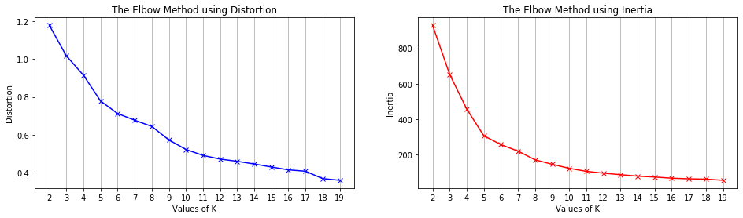

```python
# import k-means from clustering stage
from sklearn.cluster import KMeans
from sklearn import metrics
from scipy.spatial.distance import cdist

def find_k(df):
    """Function to graph distortions and inertials by k."""
    distortions = []
    inertias = []
    mapping1 = {}
    mapping2 = {}
    k_values = range(2,20)


    for k in k_values:
        #Building and fitting the model
        kmeanModel = KMeans(n_clusters=k, random_state=0).fit(df)

        distortions.append(sum(np.min(cdist(df, kmeanModel.cluster_centers_,
                          'euclidean'),axis=1)) / df.shape[0])
        inertias.append(kmeanModel.inertia_)

        mapping1[k] = sum(np.min(cdist(df, kmeanModel.cluster_centers_,
                     'euclidean'),axis=1)) / df.shape[0]
        mapping2[k] = kmeanModel.inertia_

    # Plot Distortion and Inertial to find the optimal k
    fig,(ax1,ax2) = plt.subplots(1, 2, figsize = (16,4))

    ax1.plot(k_values, distortions, 'bx-')
    ax1.set_xlabel('Values of K')
    ax1.set_xticks(list(range(2,20)))
    ax1.set_ylabel('Distortion')
    ax1.grid(axis='x')
    ax1.set_title('The Elbow Method using Distortion')

    ax2.plot(k_values, inertias, 'rx-')
    ax2.set_xlabel('Values of K')
    ax2.set_xticks(list(range(2,20)))
    ax2.set_ylabel('Inertia')
    ax2.grid(axis='x')
    ax2.set_title('The Elbow Method using Inertia')

    plt.show()

# Plot
find_k(alt_crime_norm.iloc[:,3:alt_crime_norm.shape[1]])
```

Looking at the elbow, we can get k = 5. Let's run it again to get the label.

```python
kclusters = 5
kmeans = KMeans(n_clusters=kclusters, random_state=0).fit(alt_crime_norm.iloc[:,3:alt_hood_crime.shape[1]])
alt_crime_norm_clustering_label = alt_crime_norm.copy()
alt_crime_norm_clustering_label['crime_cluster'] = kmeans.labels_
alt_crime_norm_clustering_label.head()
```

|  | Neighborhood | Latitude | Longitude | AGG ASSAULT | AUTO THEFT | BURGLARY | HOMICIDE | LARCENY | MANSLAUGHTER | ROBBERY | crime_cluster |
| --- | --- | --- | --- | --- | --- | --- | --- | --- | --- | --- | --- |
| 0 | Adair Park | 33.729698 | -84.410426 | 0.584216 | 0.545065 | 0.586769 | 1.334277 | 0.052178 | -0.086209 | 0.749336 | 0 |
| 1 | Adams Park | 33.713987 | -84.460214 | 0.092016 | 0.056470 | 0.533137 | 0.026315 | -0.053540 | -0.086209 | 0.290358 | 0 |
| 2 | Adamsville | 33.758748 | -84.503608 | 1.205326 | 0.808421 | 0.848227 | 1.043619 | 0.316758 | -0.086209 | 1.158015 | 0 |
| 3 | Almond Park | 33.784186 | -84.460470 | 0.150611 | -0.116790 | 0.110782 | 1.188948 | -0.304405 | -0.086209 | -0.068023 | 0 |
| 4 | Amal Heights | 33.708719 | -84.398984 | -0.312291 | -0.383612 | -0.331685 | -0.555002 | -0.371836 | -0.086209 | -0.445265 | 1 |

```python
import matplotlib.cm as cm
import matplotlib.colors as colors

def map_clusters_alt(df,cluster_label,cluster_no):
    # create map
    map_clusters = folium.Map(location=[latitude, longitude], zoom_start=11)

    # set color scheme for the clusters
    x = np.arange(cluster_no)
    ys = [i + x + (i*x)**2 for i in range(cluster_no)]
    colors_array = cm.rainbow(np.linspace(0, 1, len(ys)))
    rainbow = [colors.rgb2hex(i) for i in colors_array]

    # add markers to the map
    markers_colors = []
    for lat, lon, poi, cluster in zip(df['Latitude'],
                                      df['Longitude'],
                                      df['Neighborhood'],
                                      df[cluster_label]):
        label = folium.Popup(str(poi) + ' Cluster ' + str(cluster), parse_html=True)
        folium.CircleMarker(
            [lat, lon],
            radius=5,
            popup=label,
            color=rainbow[cluster-1],
            fill=True,
            fill_color=rainbow[cluster-1],
            fill_opacity=0.7).add_to(map_clusters)

    return(map_clusters)

map_clusters_alt(alt_crime_norm_clustering_label,'crime_cluster',5)
```

[interactive chart not shown]

So we have 2 big groups, one in the middle of Atlanta, and one one the outside. Let's look at the numbers of crime in detail. Remember that when doing z-score normalization, our data will be rescaled so that it has a mean of 0, and standard deviation of 1. So we are looking for negative numbers as far away from 0 as possible.

```python
 def cluster_summary(df,cluster_count,cluster_label):
    for i in range(cluster_count):
        print("Cluster {}".format(i))
        print(df[df[cluster_label]==i].shape)
        print(df[df[cluster_label]==i].mean())
        print('===========================')

cluster_summary(alt_crime_norm_clustering_label,kclusters,'crime_cluster')
```

```
Cluster 0
(50, 11)
Latitude         33.744441
Longitude       -84.406669
AGG ASSAULT       0.609881
AUTO THEFT        0.697188
BURGLARY          0.925055
HOMICIDE          0.558219
LARCENY           0.353982
MANSLAUGHTER     -0.086209
ROBBERY           0.581966
crime_cluster     0.000000
dtype: float64
===========================
Cluster 1
(177, 11)
Latitude         33.763488
Longitude       -84.443474
AGG ASSAULT      -0.435970
AUTO THEFT       -0.426486
BURGLARY         -0.501369
HOMICIDE         -0.428557
LARCENY          -0.264526
MANSLAUGHTER     -0.046757
ROBBERY          -0.403101
crime_cluster     1.000000
dtype: float64
===========================
Cluster 2
(2, 11)
Latitude         33.769332
Longitude       -84.385698
AGG ASSAULT       5.494498
AUTO THEFT        6.531219
BURGLARY          2.566138
HOMICIDE          3.586878
LARCENY           8.971326
MANSLAUGHTER     -0.086209
ROBBERY           7.171889
crime_cluster     2.000000
```

[output cut: 15 more lines]

```
===========================
Cluster 4
(13, 11)
Latitude         33.729221
Longitude       -84.417614
AGG ASSAULT       2.559327
AUTO THEFT        2.111074
BURGLARY          2.801424
HOMICIDE          2.899360
LARCENY           0.859325
MANSLAUGHTER     -0.086209
ROBBERY           2.089998
crime_cluster     4.000000
dtype: float64
===========================
```

Looking at the summary table, we can see that cluster 3 is our most dangerous clusters, with manslaughter and homicide very high. Follow by cluster 2 and 4, depends on what we are looking for. Since we want to have a safe environment, we will be picking neighborhoods from cluster 1 and 0 only. Let's try to run k-means again to see if we can further narrow down cluster 1, since they have quite a bit of neighborhoods. We will normalize data inside cluster 1 again, to have a better view of their neighborhoods.

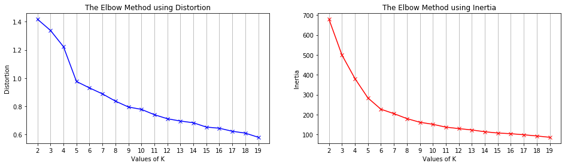

```python
cluster_0_1 = alt_crime_norm_clustering_label.loc[alt_crime_norm_clustering_label['crime_cluster']==1,:].copy()
cluster_0_1 = cluster_0_1[['Neighborhood','crime_cluster']]

safe_cluster =  alt_hood_crime.copy().merge(cluster_0_1,on='Neighborhood',right_index=False)
safe_cluster = safe_cluster[safe_cluster['crime_cluster']==1]
safe_cluster.drop('crime_cluster',axis=1,inplace=True)

#Normalize inside cluster 1
safe_cluster_norm = safe_cluster.iloc[:,3:safe_cluster.shape[1]] #get crime only
safe_cluster_norm = (safe_cluster_norm-safe_cluster_norm.mean())/safe_cluster_norm.std()
safe_cluster_norm = pd.concat([safe_cluster.iloc[:,0:3],safe_cluster_norm],axis=1)

find_k(safe_cluster_norm.iloc[:,3:safe_cluster_norm.shape[1]])
```

So we can further narrow down cluster1 into 6 smaller clusters, based on our graphs.

```python
kclusters = 6

kmeans = KMeans(n_clusters=kclusters, random_state=0).fit(safe_cluster_norm.iloc[:,3:safe_cluster_norm.shape[1]])
safe_cluster_norm['crime_cluster_narrow'] = kmeans.labels_

cluster_summary(safe_cluster_norm,kclusters,'crime_cluster_narrow')
```

```
Cluster 0
(2, 11)
Latitude                33.824763
Longitude              -84.387270
AGG ASSAULT              0.677224
AUTO THEFT               2.409881
BURGLARY                 0.849162
HOMICIDE                -0.631572
LARCENY                  7.401331
MANSLAUGHTER            -0.075165
ROBBERY                  3.367631
crime_cluster_narrow     0.000000
dtype: float64
===========================
Cluster 1
(48, 11)
Latitude                33.754017
Longitude              -84.437432
AGG ASSAULT              0.217730
AUTO THEFT               0.239551
BURGLARY                 0.284014
HOMICIDE                 0.124572
LARCENY                 -0.056091
MANSLAUGHTER            -0.075165
ROBBERY                  0.139921
crime_cluster_narrow     1.000000
dtype: float64
===========================
Cluster 2
(13, 11)
Latitude                33.733105
Longitude              -84.454592
AGG ASSAULT              2.501199
AUTO THEFT               0.627652
BURGLARY                 1.535000
HOMICIDE                 2.327859
LARCENY                 -0.132684
MANSLAUGHTER            -0.075165
ROBBERY                  1.065314
crime_cluster_narrow     2.000000
```

[output cut: 29 more lines]

```
===========================
Cluster 5
(95, 11)
Latitude                33.767437
Longitude              -84.455848
AGG ASSAULT             -0.667303
AUTO THEFT              -0.670828
BURGLARY                -0.683539
HOMICIDE                -0.532239
LARCENY                 -0.332426
MANSLAUGHTER            -0.075165
ROBBERY                 -0.659068
crime_cluster_narrow     5.000000
dtype: float64
===========================
```

```python
map_clusters_alt(safe_cluster_norm,'crime_cluster_narrow',6)
```

[interactive chart not shown]

Based on the graph and print out above, we will pick cluster 5 as our main clusters to further proceed with our analysis. In the next step, we will use venues data to analyze the neighborhoods to get the best place so we can start our housing search in.

```python
safest = safe_cluster_norm[safe_cluster_norm['crime_cluster_narrow'] == 5]


# create map
map_clusters = folium.Map(location=[latitude, longitude], zoom_start=11)

# set color scheme for the clusters

# add markers to the map
markers_colors = []
for lat, lon, poi in zip(safest['Latitude'],
                         safest['Longitude'],
                         safest['Neighborhood']):
    label = folium.Popup(str(poi), parse_html=True)
    folium.CircleMarker(
        [lat, lon],
        radius=5,
        color='red',
        popup=label,
        fill=True,
        fill_color='red',
        fill_opacity=0.7
    ).add_to(map_clusters)

map_clusters
```

[interactive chart not shown]

```python
map_clusters_alt(safest,'crime_cluster_narrow',1)
```

[output not shown]

```python
# We get the data frame back with the original crime count, in case we have to further analyze and normalize them.
final_crime = safe_cluster_norm.loc[safe_cluster_norm['crime_cluster_narrow'] == 5,['Neighborhood']]
final_crime = final_crime.merge(alt_hood_crime,on='Neighborhood',right_index=False)
final_crime.head()
```

|  | Neighborhood | Latitude | Longitude | AGG ASSAULT | AUTO THEFT | BURGLARY | HOMICIDE | LARCENY | MANSLAUGHTER | ROBBERY |
| --- | --- | --- | --- | --- | --- | --- | --- | --- | --- | --- |
| 0 | Arden/Habersham | 33.838463 | -84.400728 | 2 | 7 | 11 | 0 | 36 | 0 | 1 |
| 1 | Ardmore | 33.804977 | -84.394423 | 7 | 43 | 22 | 0 | 533 | 0 | 11 |
| 2 | Argonne Forest | 33.840779 | -84.403913 | 5 | 11 | 18 | 0 | 33 | 0 | 3 |
| 3 | Atkins Park | 33.775669 | -84.350905 | 2 | 13 | 18 | 0 | 90 | 0 | 5 |
| 4 | Atlanta Industrial Park | 33.796840 | -84.494977 | 8 | 26 | 24 | 1 | 133 | 0 | 5 |

#### Analyze Venues data

After we have narrowed down our target into 95 neighborhoods, let's take a look at venues available among them to pick the best place to live.

We'll search for the top 100 venues for each neighborhood in the dataframe. The radius is actually a tricky parameter to set. Since everybody who live in Atlanta will have a car, we don't have to narrow down our radius to couple hundreds meters. I think a sensible radius would be 5000m, about 3.1 miles. That's would make about 15 minutes drive in most city in America.

```python
CLIENT_ID = 'BHFL0RQARIH2YPHFZFHQWPDIHWJF4XC3BBY3PWEELDFDAXTZL' # your Foursquare ID
CLIENT_SECRET = 'ARGKXWTQXFUJHASLN0NDVD4G2KOWC2L03MOO01G4SHW3QW0D' # your Foursquare Secret
VERSION = '20200410' # Foursquare API version
RADIUS = 5000

print('Your credentails:')
print('CLIENT_ID: ' + CLIENT_ID)
print('CLIENT_SECRET:' + CLIENT_SECRET)
print('RADIUS:' + str(RADIUS))
```

```
Your credentails:
CLIENT_ID: BHFL0RQARIH2YPHFZFHQWPDIHWJF4XC3BBY3PWEELDFDAXTZL
CLIENT_SECRET:ARGKXWTQXFUJHASLN0NDVD4G2KOWC2L03MOO01G4SHW3QW0D
RADIUS:5000
```

```python
atl_venues = getNearbyVenues(group_names=final_crime['Neighborhood'],
                          location_col_name = 'Neighborhood',
                          latitudes=final_crime['Latitude'],
                          longitudes=final_crime['Longitude'],
                          limit=100,
                          radius=5000
                         )
```

```
Arden/Habersham
Ardmore
Argonne Forest
Atkins Park
Atlanta Industrial Park
Audobon Forest
Audobon Forest West
Bakers Ferry
Bankhead Courts
Ben Hill Acres
Ben Hill Forest
Bolton Hills
Boulder Park
Brandon
Brentwood
Briar Glen
Brookhaven
Brookwood Hills
Buckhead Heights
Butner/Tell
Cascade Green
Castlewood
Chalet Woods
Channing Valley
Chastain Park
Chattahoochee
Collier Hills
Collier Hills North
Colonial Homes
Druid Hills
East Ardley Road
Edmund Park
Elmco Estates
Englewood Manor
Fairburn Road/Wisteria Lane
Fairburn Tell
Fairway Acres
Fernleaf
Fort McPherson
Georgia Tech
```

[output cut: 40 more lines]

```
Springlake
State Facility
Tampa Park
Tuxedo Park
Wesley Battle
West Manor
West Paces Ferry/Northside
Westminster/Milmar
Westover Plantation
Whitewater Creek
Whittier Mill Village
Wildwood Forest
Wisteria Gardens
Woodfield
Wyngate
```

```python
print(atl_venues.shape)
atl_venues.head()
```

```
(9058, 7)
```

|  | Neighborhood | Neighborhood Latitude | Neighborhood Longitude | Venue | Venue Latitude | Venue Longitude | Venue Category |
| --- | --- | --- | --- | --- | --- | --- | --- |
| 0 | Arden/Habersham | 33.838463 | -84.400728 | Atlanta History Center | 33.842171 | -84.386090 | History Museum |
| 1 | Arden/Habersham | 33.838463 | -84.400728 | The St. Regis Atlanta | 33.839928 | -84.382559 | Hotel |
| 2 | Arden/Habersham | 33.838463 | -84.400728 | Umi Sushi | 33.839602 | -84.381989 | Sushi Restaurant |
| 3 | Arden/Habersham | 33.838463 | -84.400728 | Fellini's Pizza | 33.831568 | -84.385158 | Pizza Place |
| 4 | Arden/Habersham | 33.838463 | -84.400728 | Chops Lobster Bar | 33.840187 | -84.381725 | Steakhouse |

```
Butner/Tell                100
Chastain Park              100
Brookwood Hills            100
Heritage Valley            100
Chalet Woods               100
                          ...
Laurens Valley              53
Atlanta Industrial Park     53
Horseshoe Community         44
Magnum Manor                42
East Ardley Road            41
Name: Neighborhood, Length: 95, dtype: int64
```

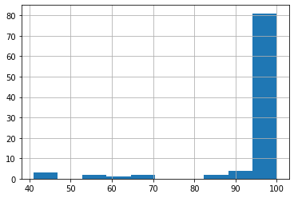

```python
print(atl_venues['Neighborhood'].value_counts())
atl_venues['Neighborhood'].value_counts().hist()
```

Looking at the histogram, there are couple of neighborhoods with not a lot of venues in them. What's not a lot depends on your definition, but we will define here as less than 50 venues in a 3 miles radius.

```python
less_than_50 = atl_venues['Neighborhood'].value_counts()[atl_venues['Neighborhood'].value_counts() < 50].index
print(less_than_50)
atl_less50 = atl_venues.loc[atl_venues['Neighborhood'].isin(less_than_50),:]

# create map
map_clusters = folium.Map(location=[latitude, longitude], zoom_start=11)

# set color scheme for the clusters

# add markers to the map
markers_colors = []
for lat, lon, poi in zip(atl_less50['Neighborhood Latitude'],
                         atl_less50['Neighborhood Longitude'],
                         atl_less50['Neighborhood']):
    label = folium.Popup(str(poi), parse_html=True)
    folium.CircleMarker(
        [lat, lon],
        radius=5,
        color='yellow',
        popup=label,
        fill=True,
        fill_color='blue'
    ).add_to(map_clusters)

map_clusters
```

```
Index(['Horseshoe Community', 'Magnum Manor', 'East Ardley Road'], dtype='object')
```

[interactive chart not shown]

So the one with less than 50 venues are kind of out there. However, since they don't negatively affect our analysis, less leave them in there. Next, let's take a look at the category of the venues.

Actually, before that, we will define our venues of interest in this step, since there will be a lot of different type of venues avaialble. We love Vietnamese food, and Asian food in general. We will also need somewhere to buy food, gas, and work out. So we will try to find quantifying

- Vietnamese Food
- Asian food
- Grocery Store/Supermarket
- Hospital
- Gas station
- Gym
- Park
- Bank

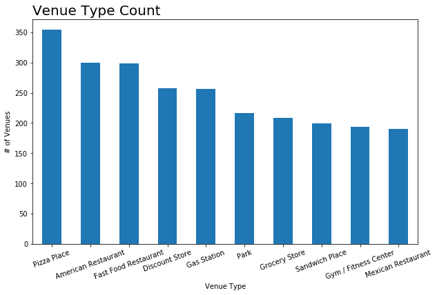

```python
venue_top10 = atl_venues['Venue Category'].value_counts()[0:10]

venue_top10.plot(kind='bar',figsize=(10, 6))

plt.xlabel('Venue Type') # add to x-label to the plot
plt.ylabel('# of Venues') # add y-label to the plot
plt.title('Venue Type Count',fontsize = 20,loc='left')
plt.xticks(rotation=20)

plt.show()
```

```python
np.sort(atl_venues['Venue Category'].unique())
```

```
array(['ATM', 'Accessories Store', 'African Restaurant', 'Airport',
       'American Restaurant', 'Animal Shelter', 'Antique Shop',
       'Aquarium', 'Arcade', 'Art Gallery', 'Art Museum',
       'Arts & Crafts Store', 'Arts & Entertainment', 'Asian Restaurant',
       'Athletics & Sports', 'Automotive Shop', 'BBQ Joint', 'Bagel Shop',
       'Bakery', 'Bank', 'Bar', 'Baseball Field', 'Baseball Stadium',
       'Basketball Stadium', 'Beer Bar', 'Beer Store', 'Big Box Store',
       'Bistro', 'Bookstore', 'Botanical Garden', 'Boutique',
       'Bowling Alley', 'Brazilian Restaurant', 'Breakfast Spot',
       'Brewery', 'Bridal Shop', 'Bridge', 'Buffet', 'Building',
       'Burger Joint', 'Burrito Place', 'Bus Station', 'Business Service',
       'Café', 'Cajun / Creole Restaurant', 'Campground',
       'Caribbean Restaurant', 'Cemetery', 'Chinese Restaurant',
       'Chocolate Shop', 'Circus', 'Clothing Store', 'Cocktail Bar',
       'Coffee Shop', 'College & University', 'College Rec Center',
       'Comedy Club', 'Concert Hall', 'Construction & Landscaping',
       'Convenience Store', 'Convention Center', 'Cosmetics Shop',
       'Cuban Restaurant', 'Cupcake Shop', 'Dance Studio',
       'Deli / Bodega', 'Department Store', 'Dessert Shop', 'Diner',
       'Discount Store', 'Dive Bar', "Doctor's Office", 'Dog Run',
       'Donut Shop', 'Drive-in Theater', 'Drugstore', 'Electronics Store',
       'Farmers Market', 'Fast Food Restaurant', 'Field',
       'Fish & Chips Shop', 'Fish Market', 'Food', 'Food & Drink Shop',
       'Food Service', 'Food Truck', 'Football Stadium', 'Fountain',
       'French Restaurant', 'Fried Chicken Joint', 'Frozen Yogurt Shop',
       'Furniture / Home Store', 'Garden', 'Garden Center', 'Gas Station',
       'Gastropub', 'Gay Bar', 'General Entertainment', 'General Travel',
       'Gift Shop', 'Golf Course', 'Golf Driving Range', 'Gourmet Shop',
       'Greek Restaurant', 'Grocery Store', 'Gun Range', 'Gun Shop',
       'Gym', 'Gym / Fitness Center', 'Gymnastics Gym', 'Hardware Store',
       'Hawaiian Restaurant', 'Health & Beauty Service',
       'Health Food Store', 'High School', 'Historic Site',
       'History Museum', 'Hobby Shop', 'Hookah Bar', 'Hot Dog Joint',
       'Hotel', 'Hotel Bar', 'Ice Cream Shop', 'Indian Restaurant',
       'Intersection', 'Irish Pub', 'Italian Restaurant',
       'Japanese Restaurant', 'Jewelry Store', 'Juice Bar', 'Kids Store',
       'Kitchen Supply Store', 'Korean Restaurant', 'Lake',
       'Latin American Restaurant', 'Laundromat', 'Light Rail Station',
       'Lingerie Store', 'Liquor Store', 'Lounge', 'Malay Restaurant',
       'Market', 'Martial Arts Dojo', 'Massage Studio',
```

[output cut: 17 more lines]

```
       'Shoe Store', 'Shopping Mall', 'Shopping Plaza', 'Skate Park',
       'Skating Rink', 'Smoke Shop', 'Smoothie Shop', 'Snack Place',
       'Soccer Field', 'Soup Place', 'Southern / Soul Food Restaurant',
       'Souvenir Shop', 'Spa', 'Spanish Restaurant', 'Speakeasy',
       'Sporting Goods Shop', 'Sports Bar', 'Sports Club', 'Stables',
       'Stadium', 'Steakhouse', 'Storage Facility', 'Supermarket',
       'Supplement Shop', 'Sushi Restaurant', 'Taco Place',
       'Tapas Restaurant', 'Tattoo Parlor', 'Tennis Court',
       'Tex-Mex Restaurant', 'Thai Restaurant', 'Theater', 'Theme Park',
       'Theme Park Ride / Attraction', 'Thrift / Vintage Store', 'Trail',
       'Vegetarian / Vegan Restaurant', 'Video Game Store', 'Video Store',
       'Vietnamese Restaurant', 'Volleyball Court', 'Warehouse Store',
       'Waste Facility', 'Weight Loss Center', 'Whisky Bar', 'Wine Bar',
       'Wine Shop', 'Wings Joint', "Women's Store", 'Yoga Studio', 'Zoo',
       'Zoo Exhibit'], dtype=object)
```

Let's narrow down the venues. First, let's remove Road, Intersection, Hotel Bar, Hotel Pool

```python
def rmv_success(term):
    unique_array = np.sort(atl_venues['Venue Category'].unique())
    if not(term in unique_array):
        print("{} successufully removed.".format(term))
    else:
        print("{} not successufully removed.".format(term))

atl_venues = atl_venues.loc[
    ~atl_venues['Venue Category'].isin(['Hotel Bar','Hotel Pool'])
]

atl_venues = atl_venues[atl_venues['Venue Category'] != 'Road']
atl_venues = atl_venues[atl_venues['Venue Category'] != 'Intersection']


rmv_success('Hotel Bar')
rmv_success('Hotel Pool')
rmv_success('Road')
rmv_success('Intersection')
```

```
Hotel Bar successufully removed.
Hotel Pool successufully removed.
Road successufully removed.
Intersection successufully removed.
```

Let's group categories based on our interest

```python
venues_df = atl_venues.copy()
venues_df.rename({'Venue Category':'v_cat'},axis=1,inplace=True)

other_asian_rest = ['Thai Restaurant','Sushi Restaurant','Poke Place','Korean Restaurant','Japanese Restaurant',
                    'Indian Restaurant','Chinese Restaurant','Asian Restaurant'
                   ]

# Drug Stores
drug_pharmacy = ['DrugStore','Drugstore','Pharmacy',"Doctor's Office",'Optical Shop','Eye Doctor',
                'Frame Store']


conditions = [
    (venues_df['v_cat'] == 'Vietnamese Restaurant'),
    (venues_df['v_cat'] == 'Park'),
    (venues_df['v_cat'].isin(other_asian_rest)),
    (venues_df['v_cat'] == 'Bank'),
    (venues_df['v_cat'].isin(drug_pharmacy)),
    (venues_df['v_cat'].str.lower().str.contains('gym')),
    (venues_df['v_cat'] == 'Gas Station'),
    ((venues_df['v_cat'].str.lower().str.contains('market')) |
     (venues_df['v_cat'].str.lower().str.contains('grocery')))
]

choices = [
    'Vietnamese Restaurant',
    'Park',
    'Other Asian Restaurant',
    'Bank',
    'Drug/Pharmacy',
    'Gym',
    'Gas Station',
    'Food Market'
]

venues_df['cat_simplified'] = np.select(conditions,choices,default='Other')
venues_df['cat_simplified'].unique()
```

```
array(['Other', 'Other Asian Restaurant', 'Food Market', 'Gym',
       'Drug/Pharmacy', 'Park', 'Vietnamese Restaurant', 'Gas Station',
       'Bank'], dtype=object)
```

```python
venues_count = (venues_df[['cat_simplified','Neighborhood',
                                            'Neighborhood Latitude','Neighborhood Longitude']].
               groupby(['cat_simplified','Neighborhood','Neighborhood Latitude','Neighborhood Longitude']).
               size().reset_index().rename(columns={0:'count'}).
               pivot_table(index=['Neighborhood','Neighborhood Latitude','Neighborhood Longitude'],
                           columns='cat_simplified',
                           values='count',fill_value=0). # Pivot to get the count in to cols.
               reset_index(). # Get hood_npu back into the data frame
               rename_axis(None,axis=1) # Need to remove index name so it's less annoying
              )
print(venues_count.shape)
venues_count.head()
```

```
(95, 12)
```

|  | Neighborhood | Neighborhood Latitude | Neighborhood Longitude | Bank | Drug/Pharmacy | Food Market | Gas Station | Gym | Other | Other Asian Restaurant | Park | Vietnamese Restaurant |
| --- | --- | --- | --- | --- | --- | --- | --- | --- | --- | --- | --- | --- |
| 0 | Arden/Habersham | 33.838463 | -84.400728 | 0 | 1 | 5 | 0 | 5 | 85 | 2 | 2 | 0 |
| 1 | Ardmore | 33.804977 | -84.394423 | 0 | 1 | 3 | 0 | 2 | 88 | 4 | 1 | 1 |
| 2 | Argonne Forest | 33.840779 | -84.403913 | 0 | 1 | 5 | 0 | 4 | 85 | 2 | 3 | 0 |
| 3 | Atkins Park | 33.775669 | -84.350905 | 0 | 0 | 5 | 0 | 1 | 88 | 2 | 4 | 0 |
| 4 | Atlanta Industrial Park | 33.796840 | -84.494977 | 0 | 1 | 2 | 5 | 5 | 37 | 2 | 1 | 0 |

At this step, since there are many neighborhood left, we will try both running K-means and DBScan algorithm to do clustering. We hope we would get some good clusters with only couple of neighborhoods. Failing that, we will run DBScan because it's more robust when dealing with outliers.

#### K-Means Neighborhood

```python
venues_norm = venues_count.iloc[:,3:venues_count.shape[1]]
venues_norm = (venues_norm-venues_norm.mean())/venues_norm.std()

venues_norm = pd.concat([venues_count.iloc[:,0:3],venues_norm],axis=1)
venues_norm.head(3)
```

|  | Neighborhood | Neighborhood Latitude | Neighborhood Longitude | Bank | Drug/Pharmacy | Food Market | Gas Station | Gym | Other | Other Asian Restaurant | Park | Vietnamese Restaurant |
| --- | --- | --- | --- | --- | --- | --- | --- | --- | --- | --- | --- | --- |
| 0 | Arden/Habersham | 33.838463 | -84.400728 | -0.709178 | -0.606216 | 1.258372 | -0.783428 | 0.98849 | 0.598912 | -1.015320 | -0.181172 | -0.340065 |
| 1 | Ardmore | 33.804977 | -84.394423 | -0.709178 | -0.606216 | -0.131690 | -0.783428 | -0.75052 | 0.828643 | 0.491796 | -0.818630 | 2.145022 |
| 2 | Argonne Forest | 33.840779 | -84.403913 | -0.709178 | -0.606216 | 1.258372 | -0.783428 | 0.40882 | 0.598912 | -1.015320 | 0.456286 | -0.340065 |

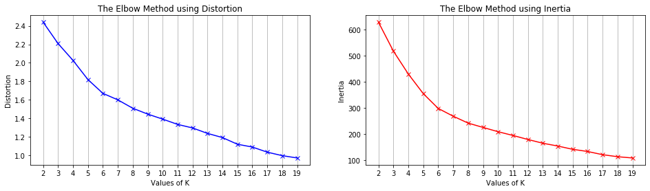

```python
find_k(venues_norm.iloc[:,3:venues_norm.shape[1]])
```

It's interesting we also have 6 clusters for this exercise. Let's take a look at them.

```python
kclusters = 6
kmeans = KMeans(n_clusters=kclusters, random_state=0).fit(venues_norm.iloc[:,3:venues_norm.shape[1]])
venues_norm_clustering_label = venues_norm.copy()
venues_norm_clustering_label['k_ne_cluster'] = kmeans.labels_

venues_norm_clustering_label.rename({'Neighborhood Latitude':'Latitude',
                                    'Neighborhood Longitude':'Longitude'},axis=1,inplace=True)

venues_norm_clustering_label.head()
```

|  | Neighborhood | Latitude | Longitude | Bank | Drug/Pharmacy | Food Market | Gas Station | Gym | Other | Other Asian Restaurant | Park | Vietnamese Restaurant | k_ne_cluster |
| --- | --- | --- | --- | --- | --- | --- | --- | --- | --- | --- | --- | --- | --- |
| 0 | Arden/Habersham | 33.838463 | -84.400728 | -0.709178 | -0.606216 | 1.258372 | -0.783428 | 0.98849 | 0.598912 | -1.015320 | -0.181172 | -0.340065 | 2 |
| 1 | Ardmore | 33.804977 | -84.394423 | -0.709178 | -0.606216 | -0.131690 | -0.783428 | -0.75052 | 0.828643 | 0.491796 | -0.818630 | 2.145022 | 0 |
| 2 | Argonne Forest | 33.840779 | -84.403913 | -0.709178 | -0.606216 | 1.258372 | -0.783428 | 0.40882 | 0.598912 | -1.015320 | 0.456286 | -0.340065 | 2 |
| 3 | Atkins Park | 33.775669 | -84.350905 | -0.709178 | -1.144445 | 1.258372 | -0.783428 | -1.33019 | 0.828643 | -1.015320 | 1.093743 | -0.340065 | 5 |
| 4 | Atlanta Industrial Park | 33.796840 | -84.494977 | -0.709178 | -0.606216 | -0.826721 | 0.670198 | 0.98849 | -3.076779 | -1.015320 | -0.818630 | -0.340065 | 3 |

```python
cluster_summary(venues_norm_clustering_label,kclusters,'k_ne_cluster')
```

```
Cluster 0
(11, 13)
Latitude                  33.795024
Longitude                -84.402733
Bank                      -0.709178
Drug/Pharmacy             -0.753006
Food Market               -0.194875
Gas Station               -0.730569
Gym                       -0.539731
Other                      0.598912
Other Asian Restaurant     1.176848
Park                       0.282433
Vietnamese Restaurant      2.596856
k_ne_cluster               0.000000
dtype: float64
===========================
Cluster 1
(15, 13)
Latitude                  33.747162
Longitude                -84.495729
Bank                      -0.374707
Drug/Pharmacy              0.398478
Food Market               -0.919392
Gas Station                1.600519
Gym                        0.099663
Other                     -0.161752
Other Asian Restaurant     0.793219
Park                       0.328794
Vietnamese Restaurant     -0.340065
k_ne_cluster               1.000000
dtype: float64
===========================
Cluster 2
(23, 13)
Latitude                  33.833429
Longitude                -84.410558
Bank                      -0.709178
Drug/Pharmacy             -0.723222
Food Market                0.653997
Gas Station               -0.720227
```

[output cut: 41 more lines]

```
(12, 13)
Latitude                  33.809861
Longitude                -84.391308
Bank                      -0.709178
Drug/Pharmacy             -0.875330
Food Market                0.910857
Gas Station               -0.662293
Gym                       -0.992049
Other                      0.681870
Other Asian Restaurant    -0.261762
Park                       1.040622
Vietnamese Restaurant     -0.340065
k_ne_cluster               5.000000
dtype: float64
===========================
```

```python
map_clusters_alt(venues_norm_clustering_label,'k_ne_cluster',6)
```

[interactive chart not shown]

Looking at the summary, we can see that for our purposes, we should can pick cluster 0 to begin looking for a place to live.

However, let's try putting some weight on the features first since we have different priorities. We want to be closer to Vietnames and Asian restaurants, and groceries the most, we will give them a squared weight. For gym and park, let's put 2. For the rest of the categories except Other, let's give them a weight of 1.5.

#### Using Weight with K-means

```python
venues_norm_weighted = venues_norm.copy()
venues_norm_weighted['Vietnamese Restaurant'] = venues_norm_weighted['Vietnamese Restaurant']**2
venues_norm_weighted['Other Asian Restaurant'] = venues_norm_weighted['Other Asian Restaurant']**2
venues_norm_weighted['Food Market'] = venues_norm_weighted['Food Market']**2

venues_norm_weighted['Gym'] = venues_norm_weighted['Gym']*2
venues_norm_weighted['Park'] = venues_norm_weighted['Park']*2

venues_norm_weighted['Bank'] = venues_norm_weighted['Bank']*1.5
venues_norm_weighted['Gas Station'] = venues_norm_weighted['Gas Station']*1.5
venues_norm_weighted['Drug/Pharmacy'] = venues_norm_weighted['Drug/Pharmacy']*1.5
```

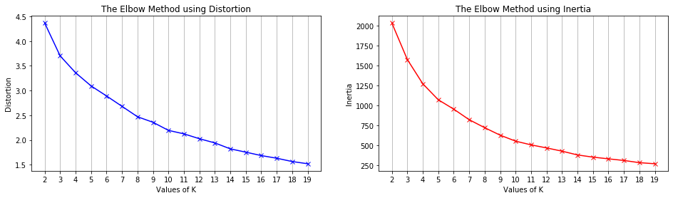

```python
find_k(venues_norm_weighted.iloc[:,3:venues_norm.shape[1]])
```

```python
kclusters = 5
kmeans = KMeans(n_clusters=kclusters, random_state=0).fit(venues_norm_weighted.iloc[:,3:venues_norm.shape[1]])
venues_norm_weighted_clustering_label = venues_norm_weighted.copy()
venues_norm_weighted_clustering_label['k_ne_cluster'] = kmeans.labels_

venues_norm_weighted_clustering_label.rename({'Neighborhood Latitude':'Latitude',
                                    'Neighborhood Longitude':'Longitude'},axis=1,inplace=True)

# Summary cluster
cluster_summary(venues_norm_clustering_label,kclusters,'k_ne_cluster')
# Print map
map_clusters_alt(venues_norm_clustering_label,'k_ne_cluster',6)
```

```
Cluster 0
(11, 13)
Latitude                  33.795024
Longitude                -84.402733
Bank                      -0.709178
Drug/Pharmacy             -0.753006
Food Market               -0.194875
Gas Station               -0.730569
Gym                       -0.539731
Other                      0.598912
Other Asian Restaurant     1.176848
Park                       0.282433
Vietnamese Restaurant      2.596856
k_ne_cluster               0.000000
dtype: float64
===========================
Cluster 1
(15, 13)
Latitude                  33.747162
Longitude                -84.495729
Bank                      -0.374707
Drug/Pharmacy              0.398478
Food Market               -0.919392
Gas Station                1.600519
Gym                        0.099663
Other                     -0.161752
Other Asian Restaurant     0.793219
Park                       0.328794
Vietnamese Restaurant     -0.340065
k_ne_cluster               1.000000
dtype: float64
===========================
Cluster 2
(23, 13)
Latitude                  33.833429
Longitude                -84.410558
Bank                      -0.709178
Drug/Pharmacy             -0.723222
Food Market                0.653997
Gas Station               -0.720227
```

[output cut: 25 more lines]

```
(26, 13)
Latitude                  33.694408
Longitude                -84.515037
Bank                       1.385856
Drug/Pharmacy              1.277586
Food Market               -0.104958
Gas Station                0.413018
Gym                       -0.594455
Other                     -0.057882
Other Asian Restaurant    -0.203796
Park                      -0.230207
Vietnamese Restaurant     -0.340065
k_ne_cluster               4.000000
dtype: float64
===========================
```

[interactive chart not shown]

#### DBScan Clustering the Neighborhoods

```python
from sklearn.cluster import DBSCAN
```

```python
alt_safe = (alt_merged.drop(alt_merged.columns[np.arange(3,9)],axis=1).
            merge(alt_merged_norm_safe[['Neighborhood','crime_clustering']],
                 how='left',
                 on='Neighborhood',
                 right_index=False)
           )
alt_safe = alt_safe[alt_safe['crime_clustering'].isin([0,1])]
alt_safe = alt_safe.loc[:,['Neighborhood','Latitude','Longitude','Gym/Health','Coffee Shop','Restaurant','Market']]

from sklearn.preprocessing import StandardScaler
Clus_dataSet = StandardScaler().fit_transform(alt_safe.drop(['Neighborhood','Latitude','Longitude'],axis=1))
```

```python
epsilon = 0.3
minimumSamples = 2
db = DBSCAN(eps=epsilon, min_samples=minimumSamples).fit(venues_norm.iloc[:,3:venues_norm.shape[1]])
labels = db.labels_
labels
```

```
array([-1,  0, -1, -1, -1, -1, -1,  1, -1, -1, -1, -1,  1, -1, -1, -1,  2,
        0,  2, -1,  3, -1, -1, -1, -1, -1,  4,  4,  5, -1,  6, -1, -1, -1,
       -1, -1, -1, -1, -1, -1, -1, -1, -1, -1, -1, -1, -1, -1, -1,  7, -1,
       -1,  8, -1,  6, -1, -1,  9, -1, -1, -1, -1, -1, -1, -1, -1,  3, -1,
       -1, -1, -1, -1, -1, -1, -1, -1, -1,  9, -1,  5, -1, -1, -1, -1, -1,
        7, -1, -1, -1, -1, -1,  8, -1, -1, -1], dtype=int64)
```

```python
pd.Series(labels).value_counts()
```

```
-1    75
 1     2
 9     2
 8     2
 7     2
 6     2
 5     2
 4     2
 3     2
 2     2
 0     2
dtype: int64
```

```python
venues_norm_db = venues_norm.copy()
venues_norm_db['db_cluster'] = labels
```

```python
cluster_summary(venues_norm_db,len(pd.Series(labels).value_counts())-1,'db_cluster')
```

```
Cluster 0
(2, 13)
Neighborhood Latitude     33.805176
Neighborhood Longitude   -84.393482
Bank                      -0.709178
Drug/Pharmacy             -0.606216
Food Market               -0.131690
Gas Station               -0.783428
Gym                       -0.750520
Other                      0.828643
Other Asian Restaurant     0.491796
Park                      -0.818630
Vietnamese Restaurant      2.145022
db_cluster                 0.000000
dtype: float64
===========================
Cluster 1
(2, 13)
Neighborhood Latitude     33.749604
Neighborhood Longitude   -84.529036
Bank                      -0.709178
Drug/Pharmacy             -0.606216
Food Market               -0.826721
Gas Station                0.960923
Gym                       -0.170850
Other                      0.369181
Other Asian Restaurant     0.491796
Park                      -0.181172
Vietnamese Restaurant     -0.340065
db_cluster                 1.000000
dtype: float64
===========================
Cluster 2
(2, 13)
Neighborhood Latitude     33.856342
Neighborhood Longitude   -84.355354
Bank                      -0.709178
Drug/Pharmacy             -1.144445
Food Market               -0.826721
Gas Station               -0.783428
```

[output cut: 105 more lines]

```
(2, 13)
Neighborhood Latitude     33.685715
Neighborhood Longitude   -84.506461
Bank                       1.440989
Drug/Pharmacy              1.546700
Food Market                0.563341
Gas Station               -0.201978
Gym                       -0.170850
Other                      0.139451
Other Asian Restaurant    -0.261762
Park                      -0.818630
Vietnamese Restaurant     -0.340065
db_cluster                 9.000000
dtype: float64
===========================
```

We can see that with the right parameter, DBScan actually is better for us to narrow down our neighborhoods.

We will pick neighborhoods in clusters 0 and 4 as our main focuses. We will also use the other clusters defined using K-means as our reserve.

```python
# Pick Main Neighborhoods
main_hood = venues_norm_db['Neighborhood'][venues_norm_db['db_cluster'].isin([0,4])].reset_index(drop=True)
# Pick Reserve Neighborhoods from K-means cluster 0, not including the one in Main Neighborhoods
reserve_hood = venues_norm_clustering_label['Neighborhood'][venues_norm_clustering_label['k_ne_cluster']==0]
reserve_hood= reserve_hood[~reserve_hood.isin(main_hood)].reset_index(drop=True)

print("The main neighborhoods we should look at are:")
for h in main_hood:
    print('\t'+h)

print("If we don't like those above, we can also look at the following neighborhoods:")
for h in reserve_hood:
    print('\t'+h)
```

```
The main neighborhoods we should look at are:
	Ardmore
	Brookwood Hills
	Collier Hills
	Collier Hills North
If we don't like those above, we can also look at the following neighborhoods:
	Channing Valley
	Englewood Manor
	Georgia Tech
	Just Us
	Pleasant Hill
	State Facility
	Whitewater Creek
```

```python
main_df = venues_norm_db[venues_norm_db['db_cluster'].isin([0,4])]
main_df = main_df[['Neighborhood','Neighborhood Latitude','Neighborhood Longitude']]
main_df.rename({'Neighborhood Latitude':'Latitude',
                                    'Neighborhood Longitude':'Longitude'},axis=1,inplace=True)
main_df['cluster'] = 'main'

reserve_df = venues_norm_clustering_label[venues_norm_clustering_label['k_ne_cluster']==0]
reserve_df = reserve_df[['Neighborhood','Latitude','Longitude']]
reserve_df = reserve_df[~reserve_df['Neighborhood'].isin(main_df['Neighborhood'])]
reserve_df['cluster'] = 'reserve'

result = pd.concat([main_df,reserve_df],axis=0).reset_index(drop=True)
result['color'] = 'blue'
result.loc[result.cluster == 'main','color'] = 'red'
print(result.shape)
result.head()
```

```
(11, 5)
```

|  | Neighborhood | Latitude | Longitude | cluster | color |
| --- | --- | --- | --- | --- | --- |
| 0 | Ardmore | 33.804977 | -84.394423 | main | red |
| 1 | Brookwood Hills | 33.805375 | -84.392540 | main | red |
| 2 | Collier Hills | 33.808558 | -84.405191 | main | red |
| 3 | Collier Hills North | 33.810262 | -84.399606 | main | red |
| 4 | Channing Valley | 33.808088 | -84.411759 | reserve | blue |

```python
result.head()
```

|  | Neighborhood | Latitude | Longitude | cluster | color |
| --- | --- | --- | --- | --- | --- |
| 0 | Ardmore | 33.804977 | -84.394423 | main | red |
| 1 | Brookwood Hills | 33.805375 | -84.392540 | main | red |
| 2 | Collier Hills | 33.808558 | -84.405191 | main | red |
| 3 | Collier Hills North | 33.810262 | -84.399606 | main | red |
| 4 | Channing Valley | 33.808088 | -84.411759 | reserve | blue |

```python
# create map
map_clusters = folium.Map(location=[latitude, longitude], zoom_start=11)

# set color scheme for the clusters

# add markers to the map

for lat, lon, poi,clu,co in zip(result['Latitude'],
                                 result['Longitude'],
                                 result['Neighborhood'],
                                 result['cluster'],
                                result['color']
                                ):
    label = folium.Popup(str(poi) + ' Cluster ' + str(clu), parse_html=True)
    folium.CircleMarker(
        [lat, lon],
        radius=5,
        color = co,
        popup=label,
        fill = True,
        fill_color= co
    ).add_to(map_clusters)

map_clusters
```

[interactive chart not shown]

## Discussion

Due to time constraints and my limited knowledge of Atlanta database, not all methods were exhausted. Also, our crime analysis would be much improved if we can also include demographic data of Atlanta, like income level, population, area size so we can use crime rate, and number of venues/1000 citizen for example. That would make the analysis much richer.

## Observations

In this exercise, we have run multiple clustering iterations to find the best place to live for a Vietnamese food lover. We found 4 main neighborhoods to start looking at, and 7 reserve neighborhoos. And our best place to live in probably inside inner Atlanta, but not near downtown or midtown Atlanta.

Our 4 best places to live are:

- Ardmore
- Brookwood Hills
- Collier Hills
- Collier Hills North

Failing to find a proper housing situation, we can always find more places to live in:

- Channing Valley
- Englewood Manor
- Georgia Tech
- Just Us
- Pleasant Hill
- State Facility
- Whitewater Creek

## Conclusion

In this exercise, we have successfully find 11 neighborhoods that are safe, and interesting (based on our own preference) to live in. Please keep in mind that when we are analyzing the safetiness of a neighborhood, due to lack of population data, we have to rely on the absolute value of the crime counts. This might not be representative of satefy and crime rate, since different neighborhoods have different population size and area.

While the analysis was promising, we can always further refine the analysis by bringing in demographic and population data, as well as things that might heavily affect our happiness like traffic and housing prices data.